# [5] Upper Urinary Tract Infection (Upper UTI): WHO AWaRe QIs analysis against gPPS data

CNPI AMR

Last compiled on Sunday 05 October, 2025

# 📊 Report Overview

This report presents a summary of the AWaRe-based quality indicator analysis based on gPPS inpatient data for Upper Urinary Tract Infection (Upper UTI).

This analytical script implements **WHO AWaRe (Access, Watch, Reserve)** antibiotic use **quality indicators (QIs)** for treating **Upper Urinary Tract Infection (Upper UTIs)** in adult inpatients with **community-acquired infections (CAIs)**. It utilises standardised data from the Global PPS (gPPS), specifically extracted from Excel-based outputs received by participating hospitals.

**Case Definition:**

**Upper Urinary Tract Infection** (Based on WHO AWaRe book)  
▸ **gPPS diagnostic code:** `Pye`  
▸ **gPPS definition:** includes pyelonephritis and catheter-associated upper urinary tract infections

The aim is to assess the appropriateness of **empirical antibiotic prescribing** for upper urinary tract infections, benchmarked against WHO AWaRe Book, and to provide structured feedback at both the hospital and ward levels. These insights support **antimicrobial stewardship efforts** by highlighting patterns of suboptimal prescribing and identifying opportunities for targeted quality improvement.

## 🎯 WHO AWaRe QIs for Upper UTI

Within the scope of the gPPS data structure, **three** QIs have been identified as compatible for evaluating Upper UTI-related empirical antibiotic prescriptions in adults with CAIs:

1. **H_UUTI_APPROP_DOSAGE**: Proportion of patients presenting with Upper UTIs prescribed the recommended total daily dose of IV antibiotics according to the WHO AWaRe Book.
2. **H_UUTI_WATCH_ABX**: Proportion of patients with Upper UTI given IV/oral AWaRe Book Watch antibiotics.
3. **H_UUTI_IV_ABX**: Proportion of patients presenting with Upper UTI given IV antibiotics.

## 💬 General Notes:

- Analysis includes only **adult patients (≥18 years)** with **CAIs** on **empirical** treatment.
- **Intravenous (IV) administration** was inferred using the gPPS `"Route"` code `"P"` (Parenteral), recognizing that it may include other parenteral routes but predominantly indicates IV use in empirical clinical practice.
- It was assumed that **WHO recommendations for upper urinary tract infection** align with the gPPS diagnostic code **`Pye`**; therefore, these cases were assessed using the WHO AWaRe classification.
- **Quality Indicators (QIs)** were mapped and interpreted based on clinical assumptions aligning WHO Book with the available **gPPS diagnostic codes**.

💡 **Reminder:** Caution is advised when interpreting results from small sample sizes (<10 patients)

# 🔍 Initial Eligible Cases Check

This section assesses whether there are enough eligible cases to support meaningful analysis.

**📅 Survey period:** 01 Feb 2025 to 05 Feb 2025

This script applies **WHO AWaRe Quality Indicators** to adult inpatients who received empirical antibiotics for community-acquired upper urinary tract infections (CA-Upper UTI).

- **Diagnostic code:** Pye
- **Total eligible cases:** 7

**⚠️ Caution:** Few eligible cases detected. Interpret results with caution.

# 🧾 Summary of Upper UTI Eligible Patients for QI Assessment

Eligible patients for **WHO AWaRe QI** assessment are defined as **adult inpatients (≥18 years)** who received **empirical antibiotics** for **CA-Upper UTI**.

This section presents both **prescription-level** and **patient-level** summaries to establish how much of the dataset is relevant for QI evaluation. It helps frame the proportion of all prescriptions that are relevant to CA-Upper UTI

## 👥 Patient-Level Summary

This table reports on unique patients in each eligibility group. It reflects the clinical burden of Upper UTI and the proportion of patients suitable for QI evaluation.

**📊 Summary:**  
Total number of patients on antibiotics: **205**  
Total number of eligible patients on antibiotics: **7**

| Patient Category | Number of Patients | Proportion of All Patients |
| --- | --- | --- |
| Number of adult patients (≥18 years) who received empirical antibiotic treatment for CAI | 132 | 64.4% |
| Number of all patients with a diagnosis of Upper UTI on any antibiotics | 18 | 8.8% |
| **Number of eligible patients:** Adult patients (≥18 years) with a diagnosis of CA-Upper UTI who were treated empirically with antibiotics | 7 | 3.4% |

## 📑 Prescription-Level Summary

**📊 Summary:**  
Total number of antibiotic prescriptions: **215**  
Total number of eligible antibiotic prescriptions: **9**

| Prescription Category | Number of Prescriptions | Proportion of All Prescriptions |
| --- | --- | --- |
| Number of empirical antibiotic prescriptions administered to adult patients (≥18 years) for CAI | 140 | 65.1% |
| Number of all antibiotic prescriptions for patients diagnosed with Upper UTI | 20 | 9.3% |
| **Number of eligible antibiotic prescriptions:** antibiotics empirically prescribed for adult patients (≥18 years) with CA-Upper UTI | 9 | 4.2% |

# 📘 WHO AWaRe-QIs Overview

This script evaluates **THREE** WHO AWaRe indicators:

1. **H_UUTI_APPROP_DOSAGE**: Proportion of patients presenting with Upper UTIs prescribed the recommended total daily dose of IV antibiotics according to the WHO AWaRe Book.
2. **H_UUTI_WATCH_ABX**: Proportion of patients with Upper UTI given IV/oral AWaRe Book Watch antibiotics..
3. **H_UUTI_IV_ABX**: Proportion of patients presenting with Upper UTI given IV antibiotics.

**🔍 WHO AWaRe Book Recommendation:**

- **- Ciprofloxacin** (500 mg q12h ORAL)

OR

- **- Cefotaxime** (1 g q8h IV/IM) **OR** **Ceftriaxone** (1 g q24h IV/IM)

AND/OR

- **- Amikacin** (15 mg/kg q24h IV)

AND/OR

- **Gentamicin** (5 mg/kg q24h IV)

**🩺 WHO AWaRe Notes:**

- This recommendation focuses on community-acquired pyelonephritis in patients with no catheter
- Step down to oral treatment is based on improvement of symptoms
- Consider amikacin or gentamicin where ESBL-producing isolates are highly prevalent
- In very sick patients, amikacin or gentamicin can be given in combination with cefotaxime or ceftriaxone

# 📌 Indicator 1 – IV Antibiotic Choice Appropriateness

> **H_UUTI_APPROP_DOSAGE:** Proportion of patients presenting with Upper UTIs prescribed the recommended total daily dose of IV antibiotics according to the WHO AWaRe Book.

## 📈 Antibiotic Choice Appropriateness for Upper UTI

This section assesses whether adult inpatients with **CA-Upper UTI** were prescribed the appropriate empirical IV antibiotics based on the WHO AWaRe Antibiotic Book.

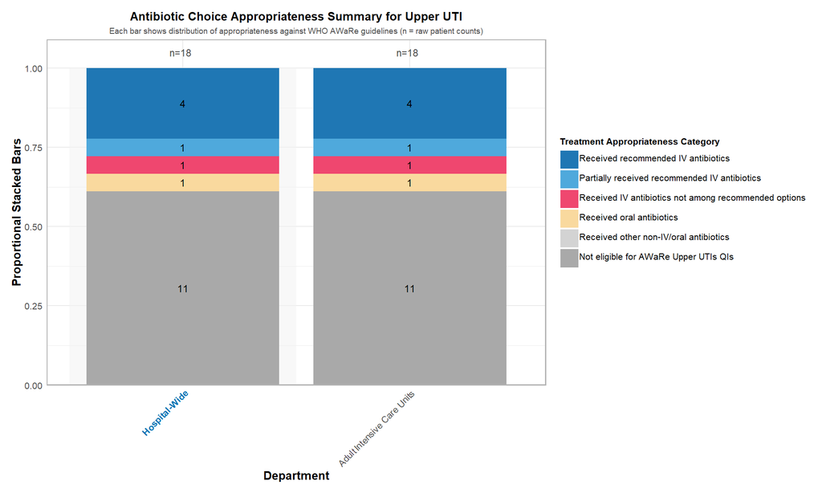

## 📝 Summary of Antibiotic Choice Appropriateness for Upper UTI

This visual summarises the proportion of antibiotic choice appropriateness for Upper UTI across hospital departments based on the WHO AWaRe Book.

💊 **Denominator:** Number of eligible upper UTI patients who received any IV antibiotic (**6** out of **7**)

**Summary:**

**🏥 Hospital-Wide** (n = 6 patients)

- ✅ **Received recommended IV antibiotics** (as per WHO AWaRe Book): **66.7%** (4 out of 6)
- ⚠️ **Partially received recommended IV antibiotics** (as per WHO AWaRe Book): **16.7%** (1 out of 6)
- ❌ **Received IV antibiotics not among recommended options** (as per WHO AWaRe Book): **16.7%** (1 out of 6)

**🏥 Adult Intensive Care Units** (n = 6 patients)

- ✅ **Received recommended IV antibiotics** (as per WHO AWaRe Book): **66.7%** (4 out of 6)
- ⚠️ **Partially received recommended IV antibiotics** (as per WHO AWaRe Book): **16.7%** (1 out of 6)
- ❌ **Received IV antibiotics not among recommended options** (as per WHO AWaRe Book): **16.7%** (1 out of 6)

## 📈 Antibiotic Choice & Dosage Appropriateness for Upper UTIs

This visual summarises the proportion of antibiotic choice & dosage appropriateness for Upper UTI across hospital departments based on the WHO AWaRe Book.

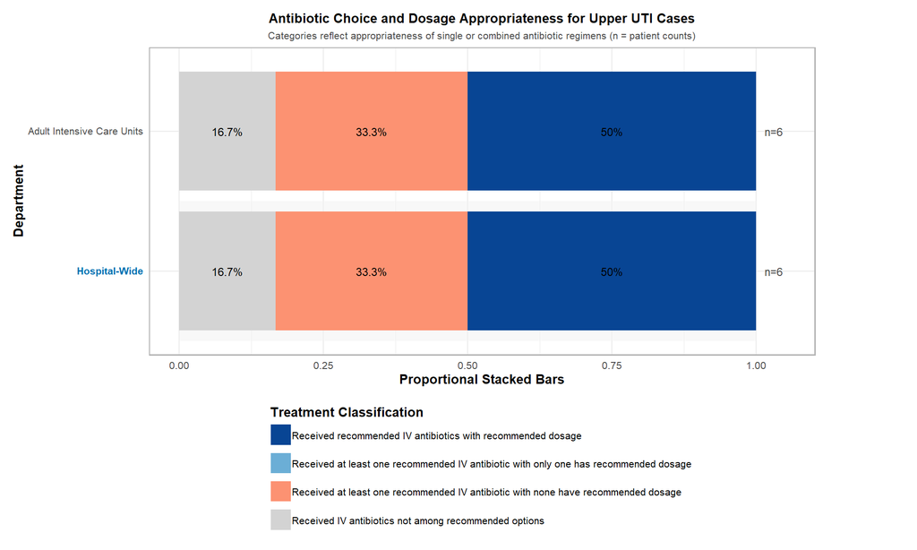

**💡 Notes:**

- **Received recommended IV antibiotics with recommended dosage** indicates that the full recommended treatment regimen (whether monotherapy or dual therapy) was given, with all dosages aligned with WHO AWaRe Book guidance.
- **Received at least one recommended IV antibiotic with one has recommended dosage** refers to cases where only part of the recommended dual therapy was given, and only one antibiotic was at the recommended dosage.
- **Received at least one recommended IV antibiotic with none have recommended dosage** includes cases who received either the full recommended regimen with no recommended dosages, or only part of it (e.g., one agent from a dual therapy) with none of the dosages aligned with WHO AWaRe Book guidance.

## 📝 Summary of Antibiotic Choice & Dosage Appropriateness for Upper UTI

This section evaluates the **appropriateness of IV antibiotic drug dosage** for patients with Upper UTIs, in line with the WHO AWaRe Book guidance.

💊 **Denominator:** Number of eligible Upper UTI patients who received recommended (*or partially recommended*) IV antibiotic choice based on WHO AWaRe Book (**5** out of 7)

**Summary:**

**🏥 Hospital-Wide** (n = 5 patients)

- ✅ **Received recommended IV antibiotics with recommended dosage** (as per WHO AWaRe Book): **60.0%** (3 out of 5)
- ⚠️ **Received at least one recommended IV antibiotic with only one has recommended dosage** (as per WHO AWaRe Book): **0.0%** (0 out of 5)
- ❌ **Received: Received at least one recommended IV antibiotic with none have recommended dosage** (as per WHO AWaRe Book): **40.0%** (2 out of 5)

**🏥 Adult Intensive Care Units** (n = 5 patients)

- ✅ **Received recommended IV antibiotics with recommended dosage** (as per WHO AWaRe Book): **60.0%** (3 out of 5)
- ⚠️ **Received at least one recommended IV antibiotic with only one has recommended dosage** (as per WHO AWaRe Book): **0.0%** (0 out of 5)
- ❌ **Received: Received at least one recommended IV antibiotic with none have recommended dosage** (as per WHO AWaRe Book): **40.0%** (2 out of 5)

# 📌 Indicator 2 - IV/Oral Watch Antibiotic Use

> **H_UUTI_WATCH_ABX:** Proportion of patients with all Upper UTIs given IV/oral Watch antibiotics.

## 📝 Summary of IV/Oral Antibiotic Use for Upper UTI

This section summarises use of IV/Oral antibiotics for patients with Upper UTI across hospital departments

💊 **Denominator:** Number of eligible Upper UTI patients who received any antibiotic (**7** out of 18)

**Summary:**

**🏥 Hospital-Wide** (n = 7 patients)

- 1 **Received a WATCH antibiotic via IV or Oral route**: **57.1%** (4 out of 7)
- 2 **Received a WATCH antibiotic via other route**: **0.0%** (0 out of 7)
- 3 **Received a NON-WATCH antibiotic**: **57.1%** (4 out of 7)

**🏥 Adult Intensive Care Units** (n = 7 patients)

- 1 **Received a WATCH antibiotic via IV or Oral route**: **57.1%** (4 out of 7)
- 2 **Received a WATCH antibiotic via other route**: **0.0%** (0 out of 7)
- 3 **Received a NON-WATCH antibiotic**: **57.1%** (4 out of 7)

**💡 Note:** The proportions are based on the number of unique Upper UTI patients per department for each specific combination of WHO AWaRe antibiotic category and route of administration. A patient contributes to the count for each distinct AWaRe category and route combination they received. Receiving the same combination multiple times does not increase the count for that combination for that patient.

## 📈 Antibiotic Prescription by AWaRe Classification

This visual summarises the proportion of antibiotic prescription for Upper UTI across hospital departments by WHO AWaRe Classification (Access, Watch, Reserve)

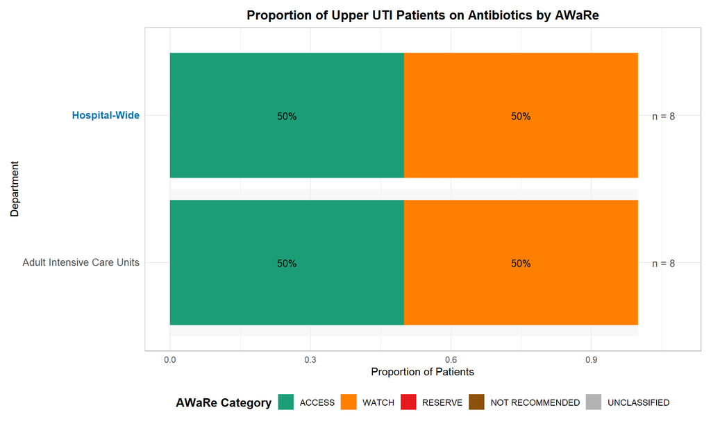

**💡 Note:** The AWaRe classification divides antibiotics into three categories: Access, Watch, and Reserve. Access antibiotics are first-line treatments with a low risk of resistance, typically recommended for common infections. Watch antibiotics are associated with a higher risk of resistance and require careful monitoring. Reserve antibiotics are reserved for critical cases involving resistant infections, typically used only when other options are ineffective .

**💡 Note:** This count in this visual represents the number of unique patients who were prescribed at least one antibiotic within a specific WHO AWaRe category (Access, Watch, or Reserve) during their encounter. A patient is counted once for each distinct AWaRe category they received an antibiotic from.

## 📈 Antibiotic Prescription by Route of Administration

This visual summarises the proportion of Upper UTI Patients on Watch Antibiotics across hospital departments by Route of Administration

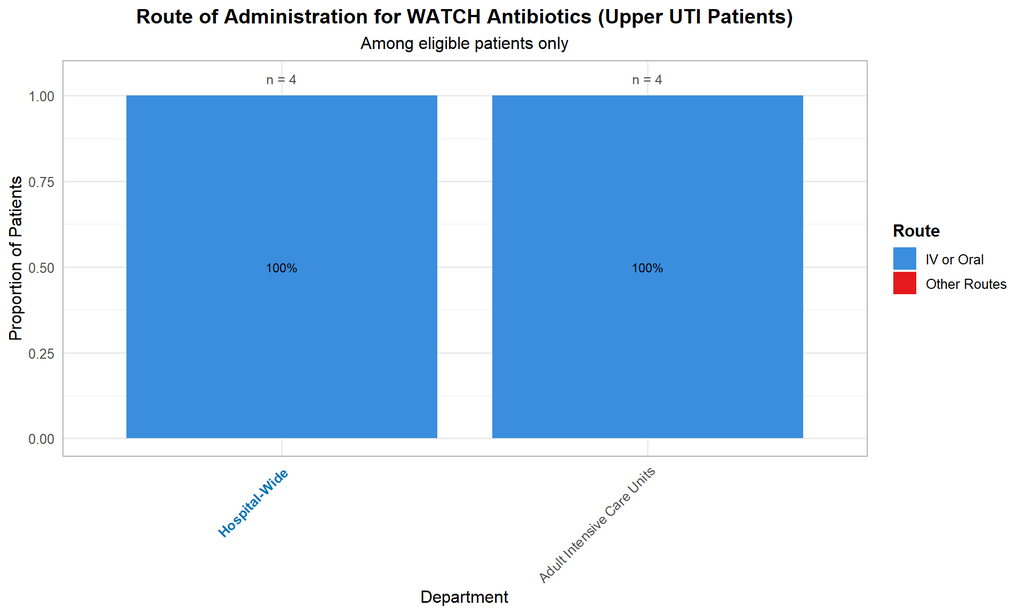

**💡 Note:** This visual shows the proportion of unique Upper UTI patients in each department who received at least one antibiotic from the WHO **Watch** category, considering the route of administration. A patient is counted once for each distinct route through which they received a Watch antibiotic.

# 📌 Indicator 3 – IV Antibiotic Use

> **H_UUTI_IV_ABX:** Proportion of patients presenting with Upper UTI given IV antibiotics.

## 📝 Summary of IV Antibiotic Use for Upper UTI

This section evaluates whether patients with **CA-Upper UTI** received empiric IV antibiotics.

💉 **Denominator:** Number of eligible Upper UTI patients who received any antibiotic (**7** out of 18)

**🏥 Hospital-Wide** (n = 7 patients)

- 1 **Received IV antibiotic**: **85.7%** (6 out of 7)
- 2 **Did not receive IV antibiotic**: **14.3%** (1 out of 7)

**🏥 Adult Intensive Care Units** (n = 7 patients)

- 1 **Received IV antibiotic**: **85.7%** (6 out of 7)
- 2 **Did not receive IV antibiotic**: **14.3%** (1 out of 7)

**💡 Note:** The proportions shown reflect the number of unique adult patients with Upper UTIs who received antibiotics via the IV or non-IV (e.g., oral or other) route. Each patient is counted only once per route category, even if multiple antibiotics were prescribed via the same route.

## 📈 Antibiotic Prescription by Route of Administration

This visual summarises the proportion of patients with Upper UTI who received an IV antibiotic across hospital departments by route of administration

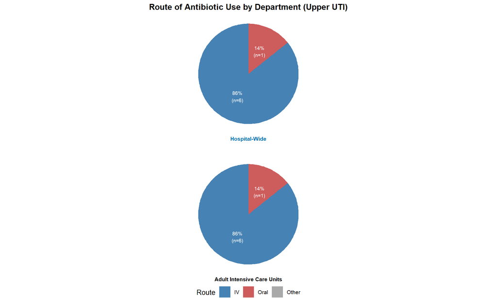